# Analytics in Practice - Assignment 2: Data Visualization

Srushti Padade

April 10, 2020

## Problem Statement

An Airport manager is receiving complaints from customers regarding the delays in departure and arrival of flights. He thinks that there are hardly any delays and even if there are any delays, it is mostly due to weather. But he is unable to convince his supervisor. He has now hired you, a Data Scientist, a graduate from Kent State University. Your job is to explain to the Airport manager about the overall delays at the Airport. You have been provided with complete air traffic data to analyze. Your task is to analyze the data and provide insights about the delays. Following are the set of questions, he is looking for an answer from you.

- To Solve the problem faced by the Airport manager we are using Data Visualization techniques to make it easier for the management to have a clear idea of the situation.
- The libraries used would be as below for the data wrangling as well as the data visualization.

```r
library(ggplot2)
library(dplyr)
library(tidyr)

options(warn = -1)
```

- Here we are loading the data set with the Flight details of the California State in United States.
- The data contained in the compressed file has been extracted from the Marketing Carrier On-Time Performance (Beginning January 2018) data table of the “On-Time” database from the TranStats data library.

```r
FlightData <- read.csv("Sample_CA_airtraffic_delays.csv")
dim(FlightData)
```

```
## [1] 6934  123
```

# 1. What is the pattern of arrival traffic and departure traffic delays with respect to days and weeks?

```r
DelayOnMonths <- FlightData %>% select("DayofMonth","DepDelay","ArrDelay", "CarrierDelay","WeatherDelay") %>% gather("Delay_Type","Delay_Time", -1) %>%
  filter(Delay_Time > 0) %>% group_by(DayofMonth,Delay_Type) %>% summarise(Frequency = n())

head(DelayOnMonths)
```

```
## # A tibble: 6 x 3
## # Groups:   DayofMonth [2]
##   DayofMonth Delay_Type   Frequency
##        <int> <chr>            <int>
## 1          1 ArrDelay            74
## 2          1 CarrierDelay        17
## 3          1 DepDelay            98
## 4          1 WeatherDelay         2
## 5          2 ArrDelay            69
## 6          2 CarrierDelay        21
```

# Answer:

- The above table is a glimpes of data that is wrangled to extract the frequency of arrival as well as departure traffic delay by filtering it from the early arrived or departed flights on DAYS of MONTHs bases.
- Also I have included Carrier and weather type delay where PURPLE represents Weather Delay which is very rare and GREEN represents Carrier Delay which also is minimal.

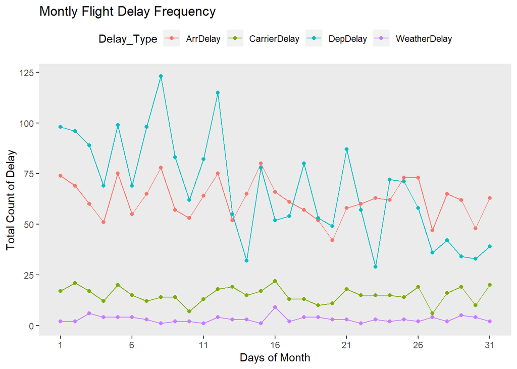

```r
ggplot(DelayOnMonths, aes(DayofMonth, Frequency)) +
  geom_line(aes(color = Delay_Type)) +
  labs(title = "Montly Flight Delay Frequency",  x = "Days of Month",  y ="Total Count of Delay") +
  geom_point(aes(color = Delay_Type)) +
  scale_x_continuous(breaks = seq(1, 31, by = 5)) +
  theme(legend.position="top", panel.grid.major = element_blank(), panel.grid.minor = element_blank())
```

- The graph displayed above represents the pattern of how the Arrival & Departure Traffic Delay is featured based on month.
- As we can see the plot there are 2 lines, RED representing Arrival Traffic Delay pattern and BLUE line representing Departure Traffic Delay pattern.
- Here we observe that the Departure traffic delay frequency varies a lot than that of Arrival Traffic. Also the delay is likely to be more at the begining of the month and then we see delay frequency going down by the end of the month.
- Below is the data that tells us the story about the Flight Delay based on DAYS OF WEEK.

```r
DelayOnWeeks <- FlightData %>% select("DayOfWeek","DepDelay","ArrDelay", "CarrierDelay","WeatherDelay") %>%
  gather("Delay_Type","Delay_Time",-1) %>%  filter(Delay_Time > 0) %>%
  group_by(DayOfWeek,Delay_Type) %>% summarise(Frequency = n())

head(DelayOnWeeks)
```

```
## # A tibble: 6 x 3
## # Groups:   DayOfWeek [2]
##   DayOfWeek Delay_Type   Frequency
##       <int> <chr>            <int>
## 1         1 ArrDelay           354
## 2         1 CarrierDelay        82
## 3         1 DepDelay           390
## 4         1 WeatherDelay        10
## 5         2 ArrDelay           303
## 6         2 CarrierDelay        82
```

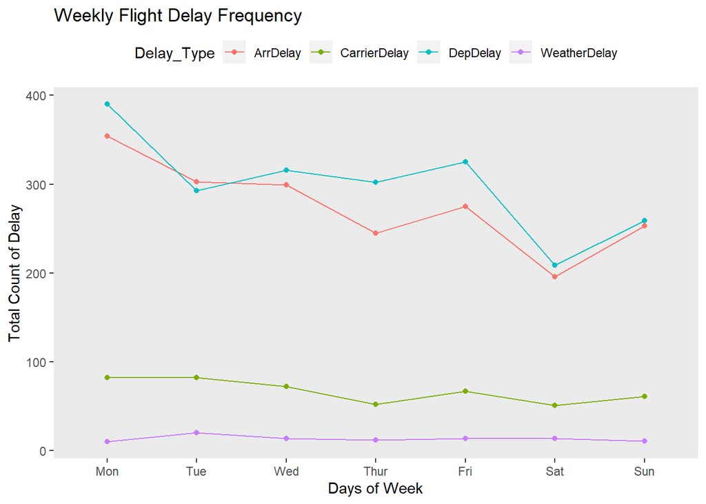

```r
ggplot(DelayOnWeeks, aes(DayOfWeek, Frequency)) +
  geom_point(aes(color = Delay_Type)) + geom_line(aes(color = Delay_Type)) +
  labs(title = "Weekly Flight Delay Frequency",  x = "Days of Week",  y ="Total Count of Delay") +
  scale_x_discrete(breaks=c("1","2","3", "4", "5", "6","7"),
  labels=c("Mon", "Tue", "Wed", "Thur", "Fri", "Sat", "Sun"), limits = c(1,2,3,4,5,6,7)) +
  theme(legend.position="top", panel.grid.major = element_blank(), panel.grid.minor = element_blank())
```

# 2. Can you interpret the traffic delays?

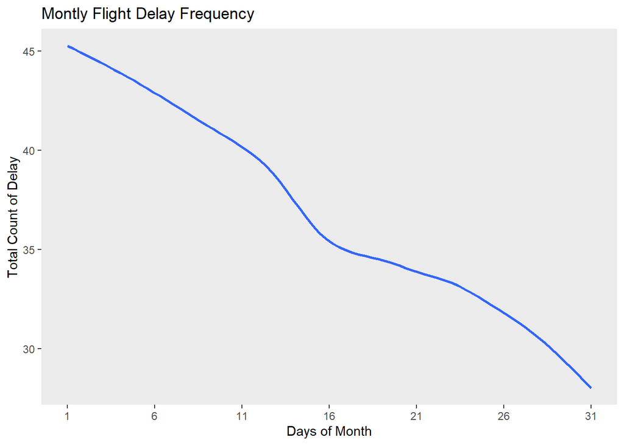

```r
# Montly Delay
ggplot(DelayOnMonths, aes(DayofMonth, Frequency)) +
  labs(title = "Montly Flight Delay Frequency",  x = "Days of Month",  y ="Total Count of Delay") +
  geom_smooth(method = "loess", se = FALSE) +
  scale_x_continuous(breaks = seq(1, 31, by = 5)) +
  theme(legend.position="top", panel.grid.major = element_blank(), panel.grid.minor = element_blank())
```

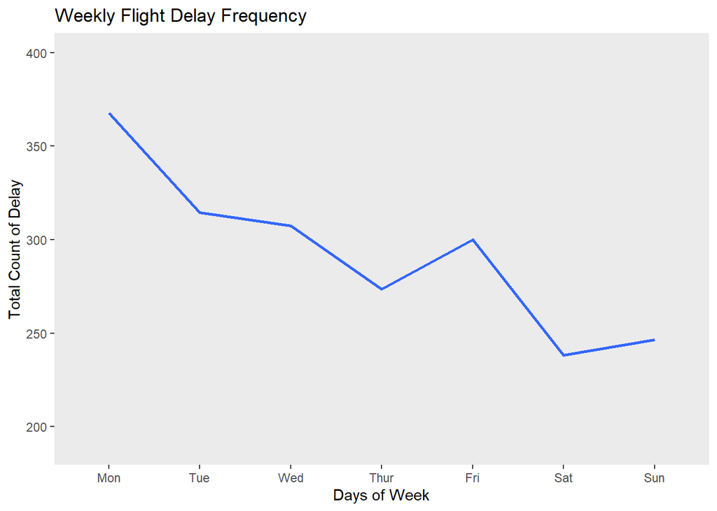

```r
# Weekly Delay
ggplot(DelayOnWeeks, aes(DayOfWeek, Frequency)) +
  geom_smooth(method = "loess", se = FALSE, size = 1) +
  labs(title = "Weekly Flight Delay Frequency",  x = "Days of Week",  y ="Total Count of Delay") +
  scale_x_discrete(breaks=c("1","2","3", "4", "5", "6","7"),
  labels=c("Mon", "Tue", "Wed", "Thur", "Fri", "Sat", "Sun"), limits = c(1,2,3,4,5,6,7)) +
  ylim(190, 400) +
  theme(legend.position="top", panel.grid.major = element_blank(), panel.grid.minor = element_blank())
```